# Научная презентация 2

Дисциплина:Операционные системы

Алехин Давид Андреевич

Российский университет дружбы народов, Москва, Россия

Математический институт имени Никольского, Москва, Россия

06.03.25

# Информация

## Докладчик

- Алехин Давид Андреевич
- Студент
- Студент НММбд-01-24
- Российский университет дружбы народов
- 1132246830@pfur.ru
- https://github.com/trustdef

[figure not shown]

# Вводная часть

## Актуальность

- Системы контроля версий (Version Control System, VCS) применяются при работе нескольких человек над одним проектом.
- При внесении изменений в содержание проекта система контроля версий позволяет их фиксировать, совмещать изменения, произведённые разными участниками проекта, производить откат к любой более ранней версии проекта, если это требуется.

## Объект и предмет исследования

- Работа с git-hub и его репозиториями
- Настройка gh и репозитория учебного курса

## Цели и задачи

- Изучить идеологию и применение средств контроля версий.
- Освоить умения по работе с git.

## Материалы и методы

- gh
- ssh key
- pgp key
- rep https://github.com/yamadharma/course-directory-student-template.

# Создание презентации

## Процессор `pandoc`

- Pandoc: преобразователь текстовых файлов
- Сайт: https://pandoc.org/
- Репозиторий: https://github.com/jgm/pandoc

## Формат `pdf`

- Использование LaTeX
- Пакет для презентации: beamer
- Тема оформления: `metropolis`

## Код для формата `pdf`

```yaml
slide_level: 2
aspectratio: 169
section-titles: true
theme: metropolis
```

## Формат `html`

- Используется фреймворк [reveal.js](https://revealjs.com/)
- Используется [тема](https://revealjs.com/themes/) `beige`

## Код для формата `html`

- Тема задаётся в файле `Makefile`

```
REVEALJS_THEME = beige
```

# Результаты

## Получающиеся форматы

- Полученный `pdf`-файл можно демонстрировать в любой программе просмотра `pdf`
- Полученный `html`-файл содержит в себе все ресурсы: изображения, css, скрипты

# Элементы презентации

## Актуальность

- Системы контроля версий (Version Control System, VCS) применяются при работе нескольких человек над одним проектом.
- При внесении изменений в содержание проекта система контроля версий позволяет их фиксировать, совмещать изменения, произведённые разными участниками проекта, производить откат к любой более ранней версии проекта, если это требуется.

## Цели и задачи

- Изучить идеологию и применение средств контроля версий.
- Освоить умения по работе с git.

## Материалы и методы

- gh
- ssh key
- pgp key
- rep https://github.com/yamadharma/course-directory-student-template.

## Содержание исследования

Устанавливаю git (рис. [-@fig:001]).

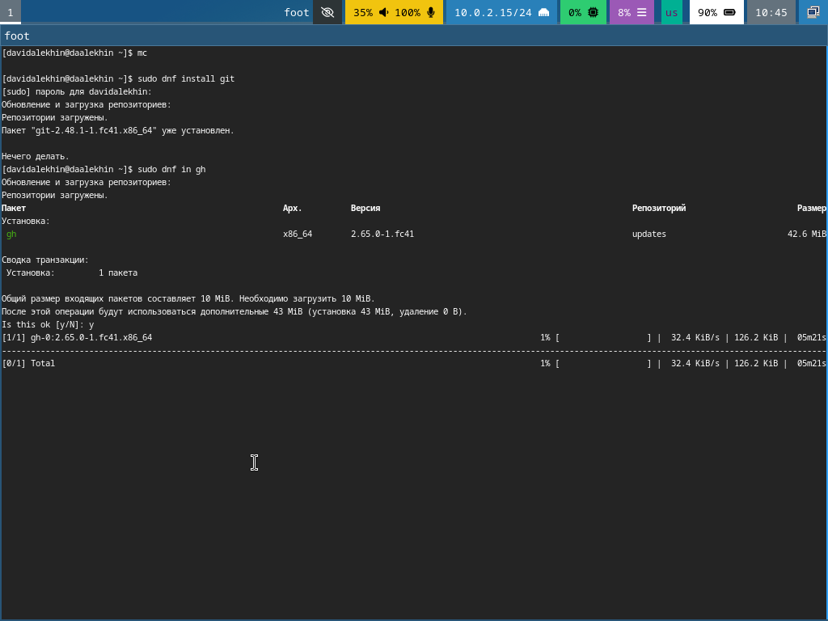

in git

## Содержание исследования

Устанавливаю gh (рис. [-@fig:002]).

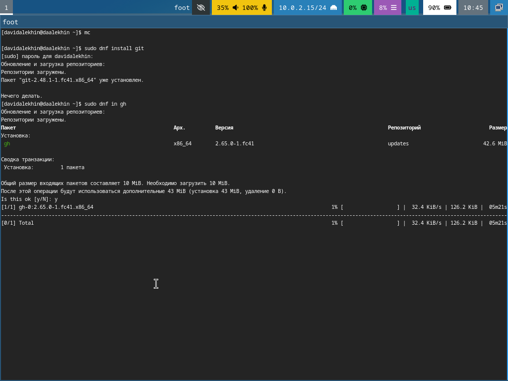

in gh

## Содержание исследования

Провожу базовую настройку гит (рис. [-@fig:003]).

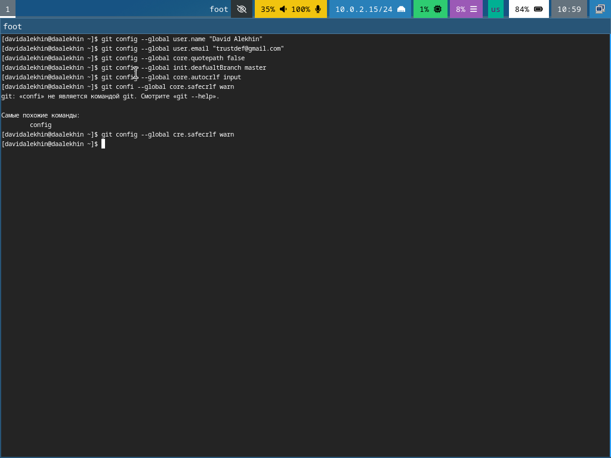

Настройка гит

## Содержание исследования

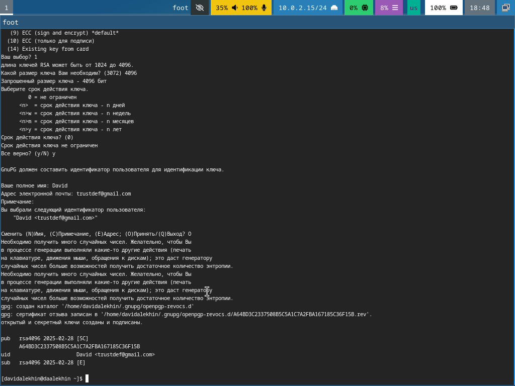

## Содержание исследования

С первого семестра у меня уже есть учётная запись git , буду работать через неё.

Копирую и добавляю pgp ключ на gh (рис. [-@fig:005]).

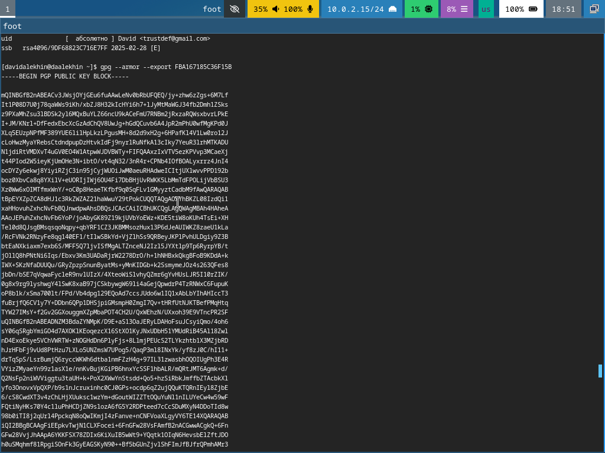

Копирую и добавляю pgp ключ на gh

## Содержание исследования

Настраиваю автоматические подписи коммитов git, а также авторизируюсь в gh (рис. [-@fig:006]).

[figure not shown]

Автоматические подписки коммитов, авторизация

## Содержание исследования

Создаю репозиторий курса (рис. [-@fig:007]).

[figure not shown]

Репозиторий курса

## Содержание исследования

Настройка каталога

Удаляю лишние каталоги (рис. [-@fig:008]).

[figure not shown]

Удаляю лишние каталоги

## Содержание исследования

Создаю необходимые каталоги (рис. [-@fig:009]).

[figure not shown]

Создаю необходимые каталоги

## Содержание исследования

Отправляю файлы на сервер(рис. [-@fig:010]).

[figure not shown]

Отправляю файлы на сервер

## Результаты

В итоге я выполнил основную цель работы: Изучить идеологию и применение средств контроля версий. Освоить умения по работе с git.

## Итоговый слайд

В теории, теория и практика неразделимы. На практике это не так. Yoggi Berra